# AML_HW1_Solutions_hk3283

## Homework 1: Applied Machine Learning

This assignment covers contents of the first three lectures.

The emphasis for this assignment would be on the following:

1. Data Visualization and Analysis
2. Linear Models for Regression and Classification
3. Support Vector Machines

```python
import warnings

def fxn():
    warnings.warn("deprecated", DeprecationWarning)

with warnings.catch_warnings():
    warnings.simplefilter("ignore")
    fxn()
```

```python
import numpy as np
import pandas as pd
import seaborn as sns
import matplotlib.pyplot as plt
from numpy.linalg import inv
%matplotlib inline
from sklearn.model_selection import train_test_split
from sklearn.preprocessing import StandardScaler, OneHotEncoder, OrdinalEncoder
from sklearn.metrics import r2_score
from sklearn.svm import LinearSVC, SVC
```

## Part 1: Data Visualization and Analysis

Data visualization comes in handy when we want to understand data characteristics and read patterns in datasets with thousands of samples and features.

**Note: Remember to label plot axes while plotting.**

### The dataset to be used for this section is bike_rental.csv.

```python
# Load the dataset
bike_rental_df = pd.read_csv('Data/bike_rental.csv')
bike_rental_df
```

|  | month | season | holiday | weekday | working_day | weather | temp | feels_temp | humidity | windspeed | casual | registered | count |
| --- | --- | --- | --- | --- | --- | --- | --- | --- | --- | --- | --- | --- | --- |
| 0 | January | winter | No | Saturday | No | cloudy | 0.344167 | 0.363625 | 0.805833 | 0.160446 | 331 | 654 | 985 |
| 1 | January | winter | No | Sunday | No | cloudy | 0.363478 | 0.353739 | 0.696087 | 0.248539 | 131 | 670 | 801 |
| 2 | January | winter | No | Monday | Yes | clear | 0.196364 | 0.189405 | 0.437273 | 0.248309 | 120 | 1229 | 1349 |
| 3 | January | winter | No | Tuesday | Yes | clear | 0.200000 | 0.212122 | 0.590435 | 0.160296 | 108 | 1454 | 1562 |
| 4 | January | winter | No | Wednesday | Yes | clear | 0.226957 | 0.229270 | 0.436957 | 0.186900 | 82 | 1518 | 1600 |
| ... | ... | ... | ... | ... | ... | ... | ... | ... | ... | ... | ... | ... | ... |
| 726 | December | winter | No | Thursday | Yes | cloudy | 0.254167 | 0.226642 | 0.652917 | 0.350133 | 247 | 1867 | 2114 |
| 727 | December | winter | No | Friday | Yes | cloudy | 0.253333 | 0.255046 | 0.590000 | 0.155471 | 644 | 2451 | 3095 |
| 728 | December | winter | No | Saturday | No | cloudy | 0.253333 | 0.242400 | 0.752917 | 0.124383 | 159 | 1182 | 1341 |
| 729 | December | winter | No | Sunday | No | clear | 0.255833 | 0.231700 | 0.483333 | 0.350754 | 364 | 1432 | 1796 |
| 730 | December | winter | No | Monday | Yes | cloudy | 0.215833 | 0.223487 | 0.577500 | 0.154846 | 439 | 2290 | 2729 |

731 rows × 13 columns

**1.1 Create a bar chart to compare the average bike rental count on holiday and non-holiday weekdays. Are there differences in rental patterns?**

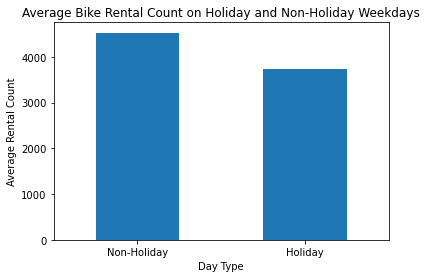

```python
### Code here

#avg_rental_count = bike_rental_df[bike_rental_df['holiday']=='Yes']['count'].mean()

avg_rental_count = bike_rental_df.groupby('holiday')["count"].mean()

fig, ax = plt.subplots()

# Plot the bar chart
avg_rental_count.plot(kind="bar", ax=ax)

# Customize the plot
ax.set_xticklabels(["Non-Holiday", "Holiday"], rotation=0)
ax.set_xlabel("Day Type")
ax.set_ylabel("Average Rental Count")
ax.set_title("Average Bike Rental Count on Holiday and Non-Holiday Weekdays")

# Show the plot
plt.show()
```

```python
### Comment here

print("There is a clear difference between the two. The rental count on non-holiday days is significantly more than the rental count on holiday days")
```

```
There is a clear difference between the two. The rental count on non-holiday days is significantly more than the rental count on holiday days
```

**1.2 Plot a small multiple of bar charts to understand data distribution of the following categorical variables.**

1. month
2. season
3. working_day
4. weather

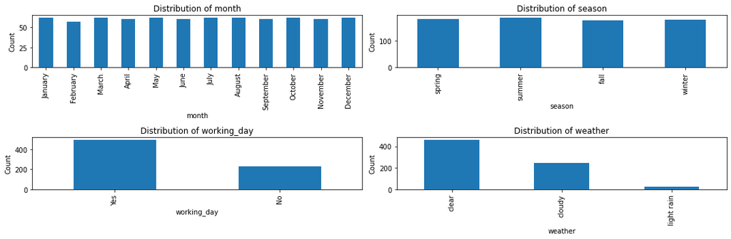

```python
### Code here

# Create a 1x3 grid of subplots for the small multiples
fig, axs = plt.subplots(2, 2, figsize=(15, 5))

axs = axs.ravel()

# Iterate through the categorical variables and create bar charts
categorical_variables = ["month", "season", "working_day", 'weather']

for i, var in enumerate(categorical_variables):
    ax = axs[i]
    counts = bike_rental_df[var].value_counts()

    if i == 0:
        counts = counts.loc[['January', 'February', 'March', 'April', 'May', 'June', 'July', 'August',
                             'September', 'October', 'November', 'December']]
    if i == 1:
        counts = counts.loc[['spring', 'summer', 'fall', 'winter']]
    if i == 2:
        counts = counts.loc[['Yes', 'No']]
    if i == 3:
        counts = counts.loc[['clear', 'cloudy', 'light rain']]

    # Create a bar chart
    pd.Series(counts).plot(kind="bar", ax=ax)

    # Customize the plot
    ax.set_title(f"Distribution of {var}")
    ax.set_xlabel(var)
    ax.set_ylabel("Count")

# Adjust layout
plt.tight_layout()

# Show the plots
plt.show()
```

**1.3 Compare the number of registered and casual bike rentals over time by month. Create a stacked bar chart to show the contributions of each user type.**

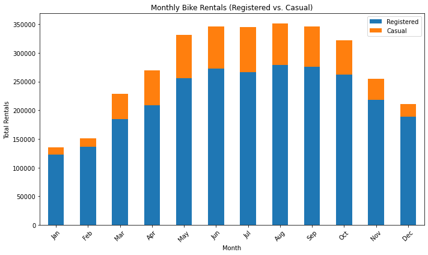

```python
### Code here

monthly_rentals = bike_rental_df.groupby(['month'])[['registered', 'casual']].sum()
monthly_rentals = monthly_rentals.loc[['January', 'February', 'March', 'April', 'May', 'June', 'July', 'August',
                             'September', 'October', 'November', 'December']]
ax = monthly_rentals.plot(kind='bar', stacked=True, figsize=(10, 6))

# Customize the plot
ax.set_xlabel("Month")
ax.set_ylabel("Total Rentals")
ax.set_title("Monthly Bike Rentals (Registered vs. Casual)")
ax.set_xticklabels(['Jan', 'Feb', 'Mar', 'Apr', 'May', 'Jun', 'Jul', 'Aug', 'Sep', 'Oct', 'Nov', 'Dec'], rotation=45)

# Add a legend
ax.legend(["Registered", "Casual"])

# Show the plot
plt.tight_layout()
plt.show()
```

**1.4 Plot relationships between the following features and the target variable count as a small multiple of scatter plots.**

1. temp
2. feels_temp
3. humidity
4. windspeed

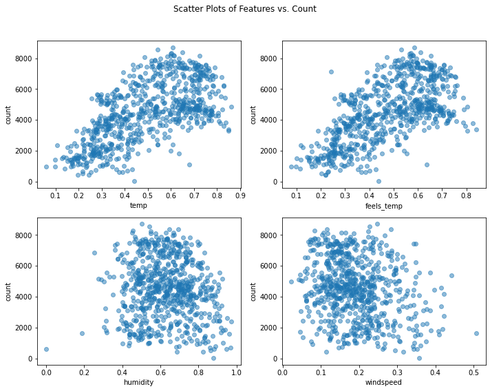

```python
### Code here

# List of features to plot
features = ["temp", "feels_temp", "humidity", "windspeed"]

# Specify the target variable
target_variable = "count"

# Create a small multiple grid of scatter plots
fig, axes = plt.subplots(nrows=2, ncols=2, figsize=(10, 8))
fig.suptitle("Scatter Plots of Features vs. Count")

for i, feature in enumerate(features):
    row = i // 2
    col = i % 2
    ax = axes[row, col]
    ax.scatter(bike_rental_df[feature], bike_rental_df[target_variable], alpha=0.5)
    ax.set_xlabel(feature)
    ax.set_ylabel(target_variable)

# Adjust layout
plt.tight_layout(rect=[0, 0, 1, 0.95])

# Show the plots
plt.show()
```

## Part 2: Linear Models for Regression and Classification

In this section, we will be implementing three linear models **linear regression, logistic regression, and SVM**. We will see that despite some of their differences at the surface, these linear models (and many machine learning models in general) are fundamentally doing the same thing - that is, optimizing model parameters to minimize a loss function on data.

### 2.1 Linear Regression

The objective of this dataset is to predict the count of bike rentals based on weather and time. We will use linear regression to predict the count using weather and time.

```python
# split data into features and labels

bike_rental_X = bike_rental_df.drop(columns=['count'])
bike_rental_y = bike_rental_df['count']
```

**2.1.1 Plot the relationships between the label (count) and the continuous features (temp, feels_temp, humidity, windspeed, casual, registered) using a small multiple of scatter plots. Make sure to label the axes.**

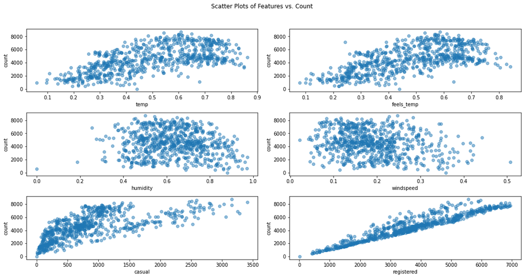

```python
### Code here

# List of features to plot
features = ["temp", "feels_temp", "humidity", "windspeed", "casual", "registered"]

# Specify the target variable
target_variable = "count"

# Create a small multiple grid of scatter plots
fig, axes = plt.subplots(nrows=3, ncols=2, figsize=(15, 8))
fig.suptitle("Scatter Plots of Features vs. Count")

for i, feature in enumerate(features):
    row = i // 2
    col = i % 2
    ax = axes[row, col]
    ax.scatter(bike_rental_df[feature], bike_rental_df[target_variable], alpha=0.5)
    ax.set_xlabel(feature)
    ax.set_ylabel(target_variable)

# Adjust layout
plt.tight_layout(rect=[0, 0, 1, 0.95])

# Show the plots
plt.show()
```

**2.1.2 From the visualizations above, do you think linear regression is a good model for this problem? Why and/or why not? Please explain.**

```python
### Comment here

print("Consider it from different features:")
print("For temp and features_temp, features are monotonically related to count up to a value, but then the relationship is reversed, so a quadratic simulation may work better, but a linear model can be used as well;")
print("For humidity and windspeed, it is difficult to see the linear pattern in this through the scatterplot, so the linear model may not work too well;")
print("For casual and registered, their linear relationship with count is so obvious that linear regression can be used.")
```

```
Consider it from different features:
For temp and features_temp, features are monotonically related to count up to a value, but then the relationship is reversed, so a quadratic simulation may work better, but a linear model can be used as well;
For humidity and windspeed, it is difficult to see the linear pattern in this through the scatterplot, so the linear model may not work too well;
For casual and registered, their linear relationship with count is so obvious that linear regression can be used.
```

### Data Preprocessing

Before we can fit a linear regression model, there are several pre-processing steps we should apply to the datasets:

1. Encode categorial features appropriately.
2. Remove highly collinear features by reading the correlation plot.
3. Split the dataset into training (60%), validation (20%), and test (20%) sets.
4. Standardize the columns in the feature matrices X_train, X_val, and X_test to have zero mean and unit variance. To avoid information leakage, learn the standardization parameters (mean, variance) from X_train, and apply it to X_train, X_val, and X_test.
5. Add a column of ones to the feature matrices X_train, X_val, and X_test. This is a common trick so that we can learn a coefficient for the bias term of a linear model.

**2.1.3 Encode the categorical variables of the Bike Rental dataset.**

```python
### Code here

season_tf = pd.get_dummies(bike_rental_X["season"])
holiday_tf = pd.get_dummies(bike_rental_X["holiday"])
weekday_tf = pd.get_dummies(bike_rental_X["weekday"])
working_day_tf = pd.get_dummies(bike_rental_X["working_day"])
weather_tf = pd.get_dummies(bike_rental_X["weather"])
month_tf = pd.get_dummies(bike_rental_X["month"])
```

```python
### Code here

holiday_tf.rename(columns={'No': 'NotIsHoliday', 'Yes': 'IsHoliday'}, inplace=True)
working_day_tf.rename(columns={'No': 'NotIsWorkingday', 'Yes': 'IsWorkingday'}, inplace=True)
```

**2.1.4 Plot the correlation matrix, and check if there is high correlation between the given numerical features (Threshold >=0.9). If yes, drop one from each pair of highly correlated features from the dataframe. Why is necessary to drop those columns before proceeding further?**

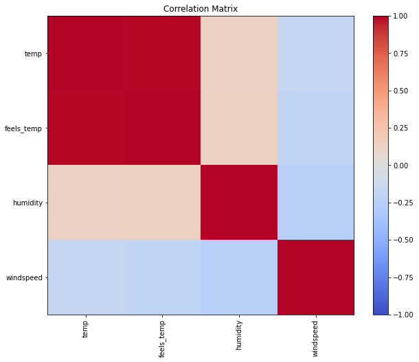

```python
### Code here

# as Ed says, just drop column Registered and Casual

bike_rental_X_numerical = bike_rental_X[['temp', 'feels_temp', 'humidity', 'windspeed']]

# Calculate the correlation matrix
correlation_matrix = bike_rental_X_numerical.corr()

plt.figure(figsize=(10, 8))
plt.title("Correlation Matrix")
plt.imshow(correlation_matrix, cmap='coolwarm', vmin=-1, vmax=1, aspect='auto')
plt.colorbar()

# Set the x and y axis labels
plt.xticks(np.arange(len(bike_rental_X_numerical.columns)), bike_rental_X_numerical.columns, rotation=90)
plt.yticks(np.arange(len(bike_rental_X_numerical.columns)), bike_rental_X_numerical.columns)

# Show the plot
plt.show()
```

```python
### Code here
highly_correlated = np.abs(correlation_matrix) >= 0.9
print(highly_correlated)
print()
print("So we drop \'temp\'")

bike_rental_X_numerical_dropped = bike_rental_X_numerical.drop(columns='temp')
```

```
             temp  feels_temp  humidity  windspeed
temp         True        True     False      False
feels_temp   True        True     False      False
humidity    False       False      True      False
windspeed   False       False     False       True

So we drop 'temp'
```

```python
### Comment here
print("The removal of highly correlated columns is necessary to avoid multicollinearity in regression models. Multicollinearity occurs when two or more independent variables in a regression model are highly correlated, making it difficult for the model to estimate their individual effects. It can lead to unstable coefficients and incorrect interpretations of the model's output. By removing one of the highly correlated features, we reduce redundancy and improve the stability and interpretability of the model.")
```

[output not shown]

**2.1.5 Split the dataset into training (60%), validation (20%), and test (20%) sets.**

```python
### Code here

# Merge data
bike_rental_X = pd.merge(season_tf, holiday_tf, left_index=True, right_index=True, how='outer')
bike_rental_X = pd.merge(bike_rental_X, weekday_tf, left_index=True, right_index=True, how='outer')
bike_rental_X = pd.merge(bike_rental_X, working_day_tf, left_index=True, right_index=True, how='outer')
bike_rental_X = pd.merge(bike_rental_X, weather_tf, left_index=True, right_index=True, how='outer')
bike_rental_X = pd.merge(bike_rental_X, month_tf, left_index=True, right_index=True, how='outer')
bike_rental_X = pd.merge(bike_rental_X, bike_rental_X_numerical_dropped, left_index=True, right_index=True, how='outer')

# At the same time, we should drop some OHE variables.
bike_rental_X = bike_rental_X.drop(columns=['winter', 'NotIsHoliday', 'Sunday', 'NotIsWorkingday', 'clear', 'December'])

# log target feature
bike_rental_y = np.log(bike_rental_y)

# First, split into training (60%) and temp (40%)
bike_rental_X_train, bike_rental_X_temp, bike_rental_y_train, bike_rental_y_temp = train_test_split(bike_rental_X, bike_rental_y, test_size=0.4, random_state=42)

# Then, split temp into validation (20%) and test (20%)
bike_rental_X_val, bike_rental_X_test, bike_rental_y_val, bike_rental_y_test = train_test_split(bike_rental_X_temp, bike_rental_y_temp, test_size=0.5, random_state=42)
```

**2.1.6 Standardize the columns in the feature matrices.**

```python
### Code here

# Initialize a StandardScaler
scaler = StandardScaler()

# Learn the standardization parameters (mean and variance) from X_train
scaler.fit(bike_rental_X_train)

# Apply the learned standardization to X_train, X_val, and X_test
X_train_standardized = scaler.transform(bike_rental_X_train)
X_val_standardized = scaler.transform(bike_rental_X_val)
X_test_standardized = scaler.transform(bike_rental_X_test)

# Convert the standardized arrays back to DataFrames
bike_rental_X_train = pd.DataFrame(X_train_standardized, columns=bike_rental_X_train.columns)
bike_rental_X_val = pd.DataFrame(X_val_standardized, columns=bike_rental_X_val.columns)
bike_rental_X_test = pd.DataFrame(X_test_standardized, columns=bike_rental_X_test.columns)

# store columns name
features_name = bike_rental_X_train.columns
```

```python
#Adding a column of ones to the feature matrices for the bias term.

bike_rental_X_train = np.hstack([np.ones((bike_rental_X_train.shape[0], 1)), bike_rental_X_train])
bike_rental_X_val = np.hstack([np.ones((bike_rental_X_val.shape[0], 1)), bike_rental_X_val])
bike_rental_X_test = np.hstack([np.ones((bike_rental_X_test.shape[0], 1)), bike_rental_X_test])
```

At the end of this pre-processing, you should have the following vectors and matrices:

- Bike Rental Prediction dataset: bike_rental_X_train, bike_rental_X_val, bike_rental_X_test, bike_rental_y_train, bike_rental_y_val, bike_rental_y_test